# Relatório Base IMDB - R para Ciência de Dados II

Géssica de Freitas

Este relatório apresenta algumas análises feitas a partir da base de dados do IMDB da Curso R. A IMDb, também conhecida como Internet Movie Database, é uma base de dados online de informação sobre cinema, TV, música e games, hoje pertencente à Amazon. Ela disponibiliza aos usuários uma série de serviços, incluindo horários de exibição de filmes nos cinemas, trailers, críticas e avaliações de usuários, está última que é popularmente utilizada como base para avaliação da qualidade de filmes.

## Algumas Curiosidades

#### 1) Geralmente em que mês do ano mais filmes são lançados?

| Mês | Nº de Filmes |
| --- | --- |
| outubro | 8706 |
| setembro | 7924 |
| março | 7435 |
| novembro | 7081 |
| abril | 7078 |
| dezembro | 6596 |

A partir da tabela acima, que mostra os meses em que mais filmes foram lançados, podemos visualizar que o mês do ano com maior número de filmes foi outubro, com 8706 novos filmes sendo lançados neste mês ao longo dos anos.

#### 2) E o dia do ano em que mais filmes são lançados?

| Dia | Nº de Filmes |
| --- | --- |
| 1 | 7226 |
| 15 | 2828 |
| 25 | 2725 |
| 14 | 2724 |
| 21 | 2646 |
| 10 | 2626 |

A partir da tabela acima, que mostra os dias em que mais filmes foram lançados, podemos visualizar que o dia do ano com maior número de filmes foi o dia 1º, com 7226 novos filmes sendo lançados neste dia ao longo dos meses e anos da base. Ou seja, o dia favorito para lançar filmes é o primeiro do mês!

#### 3) Quais países lançam mais filmes?

| País | Nº de Filmes |
| --- | --- |
| USA | 30910 |
| India | 6189 |
| UK | 5889 |
| France | 5202 |
| Italy | 3785 |

A partir da tabela acima podemos visualizar que os 5 países com mais filmes na base são, respectivamente, Estados Unidos, Índia, Reino Unido, França e Itália.

#### 4) O orçamento ou receita dos filmes aparecem, nesta base, em 79 moedas diferentes. São elas:

| Moeda |
| --- |
| $ |
| ITL |
| ROL |
| SEK |
| FRF |
| NOK |
| GBP |
| DEM |
| PTE |
| FIM |
| CAD |
| INR |
| CHF |
| ESP |
| JPY |
| DKK |
| NLG |
| PLN |
| RUR |
| AUD |
| KRW |
| BEF |
| XAU |
| HKD |
| NZD |
| CNY |
| EUR |
| PYG |
| ISK |
| IEP |
| TRL |
| HRK |
| SIT |
| PHP |
| HUF |
| DOP |
| JMD |
| CZK |
| SGD |
| BRL |
| BDT |
| ATS |
| BND |
| EGP |
| THB |
| GRD |
| ZAR |
| NPR |
| IDR |
| PKR |
| MXN |
| BGL |
| EEK |
| YUM |
| MYR |
| IRR |
| CLP |
| SKK |
| LTL |
| TWD |
| MTL |
| LVL |
| COP |
| ARS |
| UAH |
| RON |
| ALL |
| NGN |
| ILS |
| VEB |
| VND |
| TTD |
| JOD |
| LKR |
| GEL |
| MNT |
| AZM |
| AMD |
| AED |

#### 5) Dentre os filmes com orçamentos e receitas em dólar, qual gênero mais lucra?

| Gêneros | Lucro Médio |
| --- | --- |
| Animation | 132512647 |
| Adventure | 128601289 |
| Sci-Fi | 100499885 |
| Action | 76542729 |
| Fantasy | 75112790 |
| Family | 70641926 |

Quando consideramos apenas os filmes cujos orçamentos e receitas são apresentados em dólar ($) na base, podemos vizualizar, a partir da tabela acima que apresenta os gêneros com maior lucro, que o gênero Animação é o que mais lucra dentre todos, lucrando em média 132.512.647 dólares.

#### 6) Dentre os filmes com orçamentos e receitas em dólar, qual gênero tem maior nota no IMDB?

| Gêneros | Nota Média |
| --- | --- |
| Documentary | 7.500000 |
| Film-Noir | 6.951020 |
| Biography | 6.773241 |
| History | 6.612222 |
| War | 6.428637 |
| News | 6.400000 |

## E o meu filme favorito? Como ele aparece no IMDb?

É muito dificil escolher um filme favorito, mas para os propósitos desta análise, escolherem um dos meus favoritos, ele se chama “Inception”, ou, em português, “A Origem”.

[figure not shown]

**Sinópse:** Dom Cobb é um ladrão com a rara habilidade de roubar segredos do inconsciente, obtidos durante o estado de sono. Impedido de retornar para sua família, ele recebe a oportunidade de se redimir ao realizar uma tarefa aparentemente impossível: plantar uma ideia na mente do herdeiro de um império. Para realizar o crime perfeito, ele conta com a ajuda do parceiro Arthur, o discreto Eames e a arquiteta de sonhos Ariadne. Juntos, eles correm para que o inimigo não antecipe seus passos.

#### Algumas informações sobre ele:

| Título do Filme | Ano de lançamento | Nome do diretor | Nota IMDb | Lucro |
| --- | --- | --- | --- | --- |
| Inception | 2010 | Christopher Nolan | 8.8 | 709784991 |

#### E quem é Christopher Nolan?

| Nome de nascimento | Data de nascimento | Local de nascimento | Idade |
| --- | --- | --- | --- |
| Christopher Edward Nolan | 1970-07-30 | London, England, UK | 51 |

Nolan nasceu em Londres, na Inglaterra. Ele tem, hoje, 51 anos, e dentre os filmes da base cujos orçamentos e receitas se apresentam em dólares, já dirigiu 11 filmes. São eles:

| Título do Filme | Ano de lançamento | Lucro | Nota IMDB |
| --- | --- | --- | --- |
| Following | 1998 | 42482 | 7.5 |
| Memento | 2000 | 30970386 | 8.4 |
| Insomnia | 2002 | 67758770 | 7.2 |
| Batman Begins | 2005 | 223654966 | 8.2 |
| Il cavaliere oscuro | 2008 | 820455211 | 9.0 |
| The Prestige | 2006 | 69676311 | 8.5 |
| Interstellar | 2014 | 531742056 | 8.6 |
| Il cavaliere oscuro - Il ritorno | 2012 | 831133191 | 8.4 |
| Inception | 2010 | 709784991 | 8.8 |
| Dunkirk | 2017 | 426949403 | 7.9 |
| Tenet | 2020 | -151400000 | 7.9 |

O lucro médio dos filmes digiridos por Nolan é de 323.706.161 dólares, e a média das notas do IMDB desses filmes é aproximadamente 8.21. O cara é bom!

#### Mas voltando para o Inception… Eu gosto dele, mas e o IMDB?

Considerando todos os filmes da base do IMDB, Inception está na 107ª posição no ranking de notas, de um total de 85,855 filmes. Considerando apenas os filmes com orçamentos e receitas em dolar, Inception está na 14ª posição, de um total de 9,025 filmes. Não é pouca coisa não em! Ainda, quando ordenamos esses 9,025 filmes a partir de seus lucros, vemos que Inception é o 72º filme que mais lucrou.

| Título do Filme | Data de lançamento | Diretor(a) | Nota Imdb |
| --- | --- | --- | --- |
| L’ultimo dominatore dell’aria | 2010-09-24 | M. Night Shyamalan | 4.0 |
| Un soffio per la felicità | 2010-09-24 | Jon Gunn | 7.0 |
| Il segreto di Green Knowe - From Time to Time | 2010-09-24 | Julian Fellowes | 6.7 |
| Seres: Genesis | 2010-09-24 | Angel M. Huerta | 3.8 |
| Il papà migliore del mondo | 2010-09-24 | Bobcat Goldthwait | 6.9 |
| Nude Nuns with Big Guns | 2010-09-24 | Joseph Guzman | 3.9 |
| Inception | 2010-09-24 | Christopher Nolan | 8.8 |
| Täällä Pohjantähden alla II | 2010-09-24 | Timo Koivusalo | 6.8 |
| Nightbeasts | 2010-09-24 | Wes Sullivan | 6.6 |
| La passione | 2010-09-24 | Carlo Mazzacurati | 6.2 |
| El Gran Vázquez | 2010-09-24 | Óscar Aibar | 6.2 |
| Framily | 2010-09-24 | Joachim Hedén | 6.2 |
| Elisa K | 2010-09-24 | Jordi Cadena, Judith Colell | 5.8 |
| Knerten gifter seg | 2010-09-24 | Martin Lund | 5.4 |
| Star Vehicle | 2010-09-24 | Ryan Nicholson | 3.4 |
| The Virginity Hit | 2010-09-24 | Huck Botko, Andrew Gurland | 4.6 |
| Tusen gånger starkare | 2010-09-24 | Peter Schildt | 5.2 |
| 3 harfliler: Marid | 2010-09-24 | Arkin Aktaç | 3.5 |
| Wendigo: Bound by Blood | 2010-09-24 | Len Kabasinski | 3.3 |
| La sociedad del semáforo | 2010-09-24 | Rubén Mendoza | 6.4 |

Apesar de lançados no mesmo dia, podemos ver que nenhum dos filmes se igua-la ao Inception em sua avaliação. O filme que chega mais próximo é o “Un soffio per la felicità”, que possui nota 7. Mas será que todo mundo gosta mesmo de Inception, ou algumas faixas de idade gostam mais do que outras? Vamos ver.

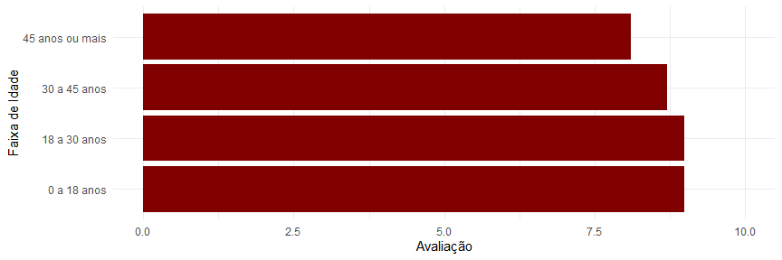

A partir do gráfico acima é possível visualizar que apesar de o filme ser um pouco menos popular entre aqueles com 45 anos ou mais, de forma geral todas as faixas etárias avaliam o filme muito bem, sempre acima de 7.5. O filme é um sucesso mesmo!

**E você, qual seu filme preferido?**